# Лабораторная работа №1

Установка и конфигурация операционной системы на виртуальную машину

Газизянов Владислав Альбертович

Российский университет дружбы народов, Москва, Россия

# Цель

## Цель

Приобритение навыков по установке операционной системы и сервисов, необходимвх для работы с ней.

# Выполнение лабораторной работы

## установка Fedora Sway и базовые настройки

[figure not shown]

Установка Fedora

## устанавливка OC

[figure not shown]

OC

## Включаем автообновления и загружаем tmux

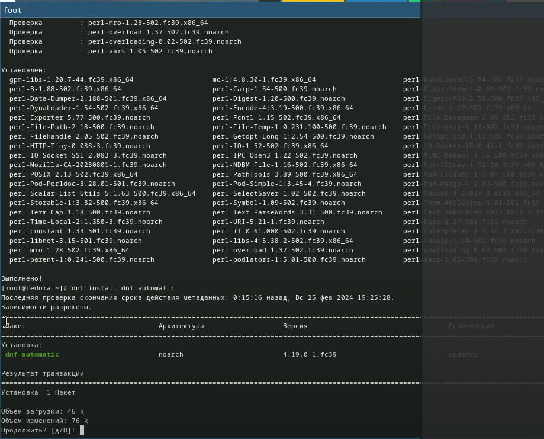

Автообновления

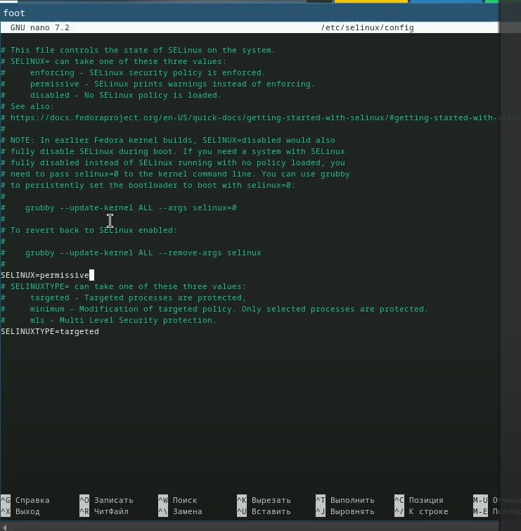

SELixnux

## обновляем драйвера

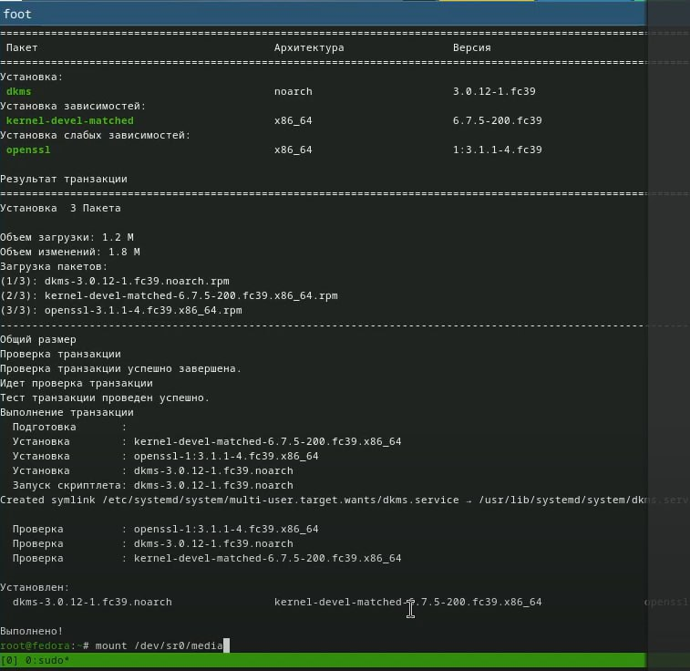

Драйвера

## меняем настройки клавиатуры

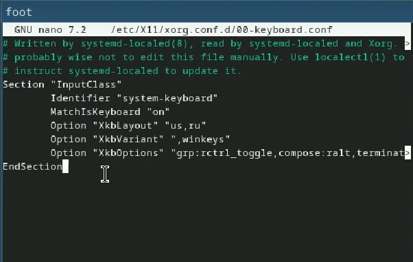

Клавиатура

## Установка имени хоста

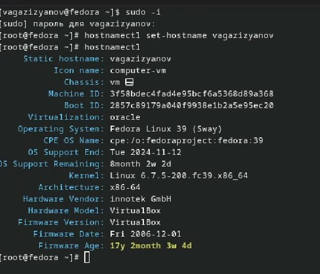

Имя хоста

## Подключаем общую папку

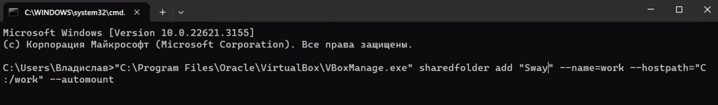

Общая папка

## СУстанавливаем Markdown and texlive

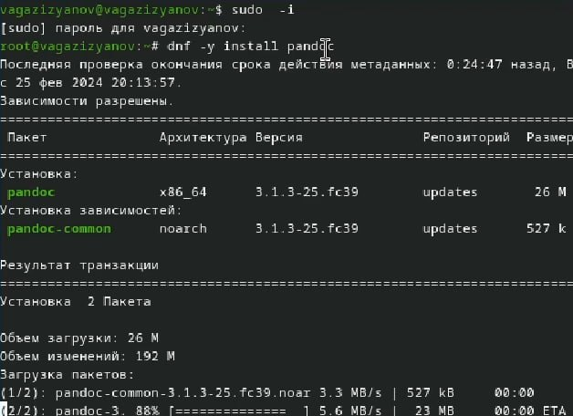

установка языка разметки

# Домашняя задание

## Домашняя задание

Следует получить следующую информацию:

Версия ядра Linux (Linux version). Частота процессора (Detected Mhz processor). Модель процессора (CPU0). Объём доступной оперативной памяти (Memory available). Тип обнаруженного гипервизора (Hypervisor detected). Тип файловой системы корневого раздела. Последовательность монтирования файловых систем.

## Домашнее задание

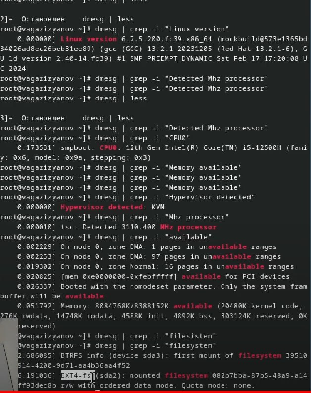

Домашняя работа

# Контрольные вопросы

## Ответы на контрольные вопросы

1. Какую информацию содержит учётная запись пользователя? -Первые буквы имени и отчества, а также фамилию
2. Укажите команды терминала и приведите примеры:

   для получения справки по команде; -man для перемещения по файловой системе; -cd для просмотра содержимого каталога; -ls для определения объёма каталога; -du для создания / удаления каталогов / файлов; -touch, mkdir, rm для задания определённых прав на файл / каталог; -chmod для просмотра истории команд. history

## Ответы на контрольные вопросы

3. Что такое файловая система? Приведите примеры с краткой характеристикой. -Это способо организации файлов и каталогов на диске. EXT2-4 - наиболее стабильная в связи с редкими изменениями кодовой базы JFS - хороша при необходимости высокой стабильности и минимальном потрелении ресурсов XFS - расчитана на файлы больших размеров, имеет незначитльеный размер служебной информации
4. Как посмотреть, какие файловые системы подмонтированы в ОС? С помощью команды mount(без аргументов)
5. Как удалить зависший процесс? Использовать команду kill

# Вывод

## Вывод

В ходе работы была установлена fedora sway на виртуальную машину, были приобретены навыки по ее установке и работе с ней.